# EDLD 652 Final Project Draft

Ksenia Gordeeva, Rebeccca Gordon, Amy Warnock

2/21/2022

```r
mathlea_10 <- get_data("EDFacts_math_achievement_lea_2010_2019")

rlalea_10 <- get_data("EDFacts_rla_achievement_lea_2010_2019")

fiscal2010 <- get_data("NCES_CCD_fiscal_district_2010")
```

### Data Visualization 1

#### Rebecca

**Research Question:**

How do high school students’ subgroup makeup (i.e., Race/ethnicity, Male vs. Female, economically disadvantaged, Limited English, Migrant status, Disability status, and Homelessness) differ among states/regions?

**Datasets:**

- EDFacts_math_achievement_lea_2010_2019
- EDFacts_rla_achievement_lea_2010_2019
- EDFacts_rla_participation_lea_2013_2019
- EDFacts_math_participation_lea_2013_2019

```r
skim(mathlea_10)
```

Data summary

| Name | mathlea_10 |
| --- | --- |
| Number of rows | 15747 |
| Number of columns | 232 |
| _______________________ |  |
| Column type frequency: |  |
| character | 118 |
| numeric | 113 |
| POSIXct | 1 |
| ________________________ |  |
| Group variables | None |

**Variable type: character**

| skim_variable | n_missing | complete_rate | min | max | empty | n_unique | whitespace |
| --- | --- | --- | --- | --- | --- | --- | --- |
| ALL_MTH00PCTPROF | 0 | 1.00 | 1 | 5 | 0 | 134 | 0 |
| ALL_MTH03PCTPROF | 1367 | 0.91 | 2 | 5 | 0 | 114 | 0 |
| ALL_MTH04PCTPROF | 1368 | 0.91 | 2 | 5 | 0 | 122 | 0 |
| ALL_MTH05PCTPROF | 1356 | 0.91 | 2 | 5 | 0 | 122 | 0 |
| ALL_MTH06PCTPROF | 1354 | 0.91 | 1 | 5 | 0 | 123 | 0 |
| ALL_MTH07PCTPROF | 1779 | 0.89 | 1 | 5 | 0 | 125 | 0 |
| ALL_MTH08PCTPROF | 1836 | 0.88 | 1 | 5 | 0 | 129 | 0 |
| ALL_MTHHSPCTPROF | 3666 | 0.77 | 1 | 5 | 0 | 131 | 0 |
| CWD_MTH00PCTPROF | 189 | 0.99 | 1 | 5 | 0 | 127 | 0 |
| CWD_MTH03PCTPROF | 2014 | 0.87 | 2 | 5 | 0 | 105 | 0 |
| CWD_MTH04PCTPROF | 2002 | 0.87 | 1 | 5 | 0 | 111 | 0 |
| CWD_MTH05PCTPROF | 2006 | 0.87 | 1 | 5 | 0 | 116 | 0 |
| CWD_MTH06PCTPROF | 2031 | 0.87 | 1 | 5 | 0 | 108 | 0 |
| CWD_MTH07PCTPROF | 2384 | 0.85 | 1 | 5 | 0 | 108 | 0 |
| CWD_MTH08PCTPROF | 2463 | 0.84 | 1 | 5 | 0 | 114 | 0 |
| CWD_MTHHSPCTPROF | 4155 | 0.74 | 1 | 5 | 0 | 108 | 0 |
| ECD_MTH00PCTPROF | 405 | 0.97 | 1 | 5 | 0 | 129 | 0 |
| ECD_MTH03PCTPROF | 1792 | 0.89 | 2 | 5 | 0 | 116 | 0 |
| ECD_MTH04PCTPROF | 1776 | 0.89 | 2 | 5 | 0 | 120 | 0 |
| ECD_MTH05PCTPROF | 1754 | 0.89 | 1 | 5 | 0 | 123 | 0 |
| ECD_MTH06PCTPROF | 1772 | 0.89 | 1 | 5 | 0 | 123 | 0 |
| ECD_MTH07PCTPROF | 2169 | 0.86 | 1 | 5 | 0 | 124 | 0 |
| ECD_MTH08PCTPROF | 2215 | 0.86 | 1 | 5 | 0 | 128 | 0 |
| ECD_MTHHSPCTPROF | 3952 | 0.75 | 1 | 5 | 0 | 130 | 0 |
| FIPST | 0 | 1.00 | 2 | 2 | 0 | 51 | 0 |
| F_MTH00PCTPROF | 47 | 1.00 | 1 | 5 | 0 | 125 | 0 |
| F_MTH03PCTPROF | 1459 | 0.91 | 2 | 5 | 0 | 105 | 0 |
| F_MTH04PCTPROF | 1467 | 0.91 | 2 | 5 | 0 | 114 | 0 |
| F_MTH05PCTPROF | 1463 | 0.91 | 2 | 5 | 0 | 115 | 0 |
| F_MTH06PCTPROF | 1460 | 0.91 | 1 | 5 | 0 | 117 | 0 |

[output cut: 88 more lines]

**Variable type: numeric**

| skim_variable | n_missing | complete_rate | mean | sd | p0 | p25 | p50 | p75 | p100 | hist |
| --- | --- | --- | --- | --- | --- | --- | --- | --- | --- | --- |
| ALL_MTH00NUMVALID | 0 | 1.00 | 1627.91 | 6374.70 | 0 | 149 | 447.0 | 1284.00 | 355121 | ▇▁▁▁▁ |
| ALL_MTH03NUMVALID | 1367 | 0.91 | 255.01 | 961.48 | 0 | 28 | 74.0 | 201.00 | 51775 | ▇▁▁▁▁ |
| ALL_MTH04NUMVALID | 1368 | 0.91 | 254.95 | 951.13 | 0 | 28 | 75.0 | 202.00 | 51736 | ▇▁▁▁▁ |
| ALL_MTH05NUMVALID | 1356 | 0.91 | 251.32 | 935.44 | 0 | 28 | 75.0 | 202.00 | 51537 | ▇▁▁▁▁ |
| ALL_MTH06NUMVALID | 1354 | 0.91 | 249.75 | 918.15 | 0 | 28 | 76.0 | 204.00 | 49264 | ▇▁▁▁▁ |
| ALL_MTH07NUMVALID | 1779 | 0.89 | 254.91 | 934.73 | 0 | 30 | 80.0 | 211.00 | 49880 | ▇▁▁▁▁ |
| ALL_MTH08NUMVALID | 1836 | 0.88 | 258.21 | 929.41 | 0 | 30 | 81.0 | 214.00 | 50322 | ▇▁▁▁▁ |
| ALL_MTHHSNUMVALID | 3666 | 0.77 | 325.95 | 1284.57 | 0 | 39 | 99.0 | 248.00 | 50607 | ▇▁▁▁▁ |
| CWD_MTH00NUMVALID | 189 | 0.99 | 214.49 | 887.63 | 0 | 21 | 60.0 | 175.00 | 58764 | ▇▁▁▁▁ |
| CWD_MTH03NUMVALID | 2014 | 0.87 | 35.38 | 138.93 | 0 | 4 | 11.0 | 29.00 | 9315 | ▇▁▁▁▁ |
| CWD_MTH04NUMVALID | 2002 | 0.87 | 36.65 | 144.13 | 0 | 4 | 11.0 | 30.00 | 9704 | ▇▁▁▁▁ |
| CWD_MTH05NUMVALID | 2006 | 0.87 | 36.25 | 143.00 | 0 | 4 | 11.0 | 30.00 | 9316 | ▇▁▁▁▁ |
| CWD_MTH06NUMVALID | 2031 | 0.87 | 35.06 | 136.40 | 0 | 4 | 11.0 | 29.00 | 8970 | ▇▁▁▁▁ |
| CWD_MTH07NUMVALID | 2384 | 0.85 | 34.82 | 139.01 | 0 | 4 | 11.0 | 29.00 | 9421 | ▇▁▁▁▁ |
| CWD_MTH08NUMVALID | 2463 | 0.84 | 34.77 | 129.70 | 0 | 4 | 12.0 | 30.00 | 7754 | ▇▁▁▁▁ |
| CWD_MTHHSNUMVALID | 4155 | 0.74 | 38.07 | 144.22 | 0 | 5 | 13.0 | 31.00 | 5312 | ▇▁▁▁▁ |
| ECD_MTH00NUMVALID | 405 | 0.97 | 834.25 | 4424.40 | 0 | 64 | 182.0 | 517.00 | 293101 | ▇▁▁▁▁ |
| ECD_MTH03NUMVALID | 1792 | 0.89 | 142.01 | 707.64 | 0 | 12 | 33.0 | 88.00 | 43322 | ▇▁▁▁▁ |
| ECD_MTH04NUMVALID | 1776 | 0.89 | 139.39 | 691.80 | 0 | 12 | 33.0 | 87.50 | 43224 | ▇▁▁▁▁ |
| ECD_MTH05NUMVALID | 1754 | 0.89 | 135.33 | 677.18 | 0 | 12 | 32.0 | 86.00 | 43027 | ▇▁▁▁▁ |
| ECD_MTH06NUMVALID | 1772 | 0.89 | 131.76 | 657.63 | 0 | 12 | 32.0 | 86.00 | 41090 | ▇▁▁▁▁ |
| ECD_MTH07NUMVALID | 2169 | 0.86 | 130.72 | 663.07 | 0 | 13 | 32.0 | 85.00 | 41130 | ▇▁▁▁▁ |
| ECD_MTH08NUMVALID | 2215 | 0.86 | 128.30 | 645.08 | 0 | 12 | 31.0 | 83.00 | 41034 | ▇▁▁▁▁ |
| ECD_MTHHSNUMVALID | 3952 | 0.75 | 137.66 | 717.20 | 0 | 14 | 33.0 | 85.50 | 40274 | ▇▁▁▁▁ |
| F_MTH00NUMVALID | 47 | 1.00 | 797.18 | 3127.18 | 0 | 73 | 219.0 | 625.25 | 174078 | ▇▁▁▁▁ |
| F_MTH03NUMVALID | 1459 | 0.91 | 124.90 | 469.39 | 0 | 14 | 36.0 | 98.00 | 25434 | ▇▁▁▁▁ |
| F_MTH04NUMVALID | 1467 | 0.91 | 125.04 | 465.82 | 0 | 14 | 37.0 | 99.00 | 25386 | ▇▁▁▁▁ |
| F_MTH05NUMVALID | 1463 | 0.91 | 123.30 | 458.45 | 0 | 14 | 37.0 | 100.00 | 25212 | ▇▁▁▁▁ |
| F_MTH06NUMVALID | 1460 | 0.91 | 122.60 | 449.49 | 0 | 14 | 37.0 | 100.00 | 23946 | ▇▁▁▁▁ |
| F_MTH07NUMVALID | 1877 | 0.88 | 125.05 | 457.22 | 0 | 15 | 39.0 | 103.00 | 24511 | ▇▁▁▁▁ |

[output cut: 83 more lines]

**Variable type: POSIXct**

| skim_variable | n_missing | complete_rate | min | max | median | n_unique |
| --- | --- | --- | --- | --- | --- | --- |
| DL_INGESTION_DATETIME | 0 | 1 | 2021-08-20 16:11:49 | 2021-08-20 16:11:49 | 2021-08-20 16:11:49 | 1 |

```r
skim(rlalea_10)
```

Data summary

| Name | rlalea_10 |
| --- | --- |
| Number of rows | 15717 |
| Number of columns | 232 |
| _______________________ |  |
| Column type frequency: |  |
| character | 118 |
| numeric | 113 |
| POSIXct | 1 |
| ________________________ |  |
| Group variables | None |

**Variable type: character**

| skim_variable | n_missing | complete_rate | min | max | empty | n_unique | whitespace |
| --- | --- | --- | --- | --- | --- | --- | --- |
| ALL_RLA00PCTPROF | 0 | 1.00 | 1 | 5 | 0 | 132 | 0 |
| ALL_RLA03PCTPROF | 1339 | 0.91 | 2 | 5 | 0 | 123 | 0 |
| ALL_RLA04PCTPROF | 1342 | 0.91 | 2 | 5 | 0 | 117 | 0 |
| ALL_RLA05PCTPROF | 1335 | 0.92 | 2 | 5 | 0 | 118 | 0 |
| ALL_RLA06PCTPROF | 1333 | 0.92 | 2 | 5 | 0 | 116 | 0 |
| ALL_RLA07PCTPROF | 1770 | 0.89 | 2 | 5 | 0 | 117 | 0 |
| ALL_RLA08PCTPROF | 1818 | 0.88 | 2 | 5 | 0 | 117 | 0 |
| ALL_RLAHSPCTPROF | 3683 | 0.77 | 2 | 5 | 0 | 118 | 0 |
| CWD_RLA00PCTPROF | 187 | 0.99 | 1 | 5 | 0 | 127 | 0 |
| CWD_RLA03PCTPROF | 1996 | 0.87 | 2 | 5 | 0 | 118 | 0 |
| CWD_RLA04PCTPROF | 1986 | 0.87 | 1 | 5 | 0 | 109 | 0 |
| CWD_RLA05PCTPROF | 1994 | 0.87 | 1 | 5 | 0 | 117 | 0 |
| CWD_RLA06PCTPROF | 2018 | 0.87 | 1 | 5 | 0 | 109 | 0 |
| CWD_RLA07PCTPROF | 2374 | 0.85 | 1 | 5 | 0 | 102 | 0 |
| CWD_RLA08PCTPROF | 2448 | 0.84 | 2 | 5 | 0 | 101 | 0 |
| CWD_RLAHSPCTPROF | 4133 | 0.74 | 1 | 5 | 0 | 99 | 0 |
| ECD_RLA00PCTPROF | 401 | 0.97 | 1 | 5 | 0 | 123 | 0 |
| ECD_RLA03PCTPROF | 1766 | 0.89 | 2 | 5 | 0 | 121 | 0 |
| ECD_RLA04PCTPROF | 1749 | 0.89 | 2 | 5 | 0 | 115 | 0 |
| ECD_RLA05PCTPROF | 1731 | 0.89 | 2 | 5 | 0 | 114 | 0 |
| ECD_RLA06PCTPROF | 1749 | 0.89 | 2 | 5 | 0 | 114 | 0 |
| ECD_RLA07PCTPROF | 2155 | 0.86 | 2 | 5 | 0 | 113 | 0 |
| ECD_RLA08PCTPROF | 2198 | 0.86 | 2 | 5 | 0 | 120 | 0 |
| ECD_RLAHSPCTPROF | 3966 | 0.75 | 2 | 5 | 0 | 119 | 0 |
| FIPST | 0 | 1.00 | 2 | 2 | 0 | 51 | 0 |
| F_RLA00PCTPROF | 40 | 1.00 | 2 | 5 | 0 | 114 | 0 |
| F_RLA03PCTPROF | 1433 | 0.91 | 2 | 5 | 0 | 118 | 0 |
| F_RLA04PCTPROF | 1441 | 0.91 | 2 | 5 | 0 | 108 | 0 |
| F_RLA05PCTPROF | 1442 | 0.91 | 2 | 5 | 0 | 104 | 0 |
| F_RLA06PCTPROF | 1440 | 0.91 | 2 | 5 | 0 | 105 | 0 |

[output cut: 88 more lines]

**Variable type: numeric**

| skim_variable | n_missing | complete_rate | mean | sd | p0 | p25 | p50 | p75 | p100 | hist |
| --- | --- | --- | --- | --- | --- | --- | --- | --- | --- | --- |
| ALL_RLA00NUMVALID | 0 | 1.00 | 1619.22 | 6341.20 | 0 | 150 | 445.0 | 1280.00 | 354300 | ▇▁▁▁▁ |
| ALL_RLA03NUMVALID | 1339 | 0.91 | 254.95 | 959.86 | 0 | 28 | 74.0 | 200.00 | 51708 | ▇▁▁▁▁ |
| ALL_RLA04NUMVALID | 1342 | 0.91 | 254.90 | 950.06 | 0 | 28 | 74.0 | 202.00 | 51714 | ▇▁▁▁▁ |
| ALL_RLA05NUMVALID | 1335 | 0.92 | 251.72 | 937.02 | 0 | 28 | 75.0 | 203.00 | 51447 | ▇▁▁▁▁ |
| ALL_RLA06NUMVALID | 1333 | 0.92 | 250.40 | 919.39 | 0 | 28 | 76.0 | 205.00 | 49186 | ▇▁▁▁▁ |
| ALL_RLA07NUMVALID | 1770 | 0.89 | 257.32 | 940.54 | 0 | 30 | 80.0 | 212.00 | 49820 | ▇▁▁▁▁ |
| ALL_RLA08NUMVALID | 1818 | 0.88 | 258.98 | 933.11 | 0 | 30 | 81.0 | 214.00 | 50401 | ▇▁▁▁▁ |
| ALL_RLAHSNUMVALID | 3683 | 0.77 | 308.21 | 1190.43 | 0 | 38 | 97.0 | 242.00 | 50027 | ▇▁▁▁▁ |
| CWD_RLA00NUMVALID | 187 | 0.99 | 213.74 | 882.36 | 0 | 21 | 60.0 | 174.00 | 58700 | ▇▁▁▁▁ |
| CWD_RLA03NUMVALID | 1996 | 0.87 | 35.38 | 138.53 | 0 | 4 | 11.0 | 29.00 | 9298 | ▇▁▁▁▁ |
| CWD_RLA04NUMVALID | 1986 | 0.87 | 36.67 | 143.98 | 0 | 4 | 11.0 | 30.00 | 9681 | ▇▁▁▁▁ |
| CWD_RLA05NUMVALID | 1994 | 0.87 | 36.30 | 142.77 | 0 | 4 | 11.0 | 30.00 | 9305 | ▇▁▁▁▁ |
| CWD_RLA06NUMVALID | 2018 | 0.87 | 35.11 | 136.29 | 0 | 4 | 11.0 | 29.00 | 8980 | ▇▁▁▁▁ |
| CWD_RLA07NUMVALID | 2374 | 0.85 | 34.99 | 139.13 | 0 | 4 | 11.0 | 29.00 | 9404 | ▇▁▁▁▁ |
| CWD_RLA08NUMVALID | 2448 | 0.84 | 35.00 | 130.36 | 0 | 4 | 12.0 | 30.00 | 7758 | ▇▁▁▁▁ |
| CWD_RLAHSNUMVALID | 4133 | 0.74 | 36.27 | 134.64 | 0 | 5 | 12.0 | 30.00 | 5096 | ▇▁▁▁▁ |
| ECD_RLA00NUMVALID | 401 | 0.97 | 829.43 | 4415.33 | 0 | 64 | 182.0 | 511.00 | 292359 | ▇▁▁▁▁ |
| ECD_RLA03NUMVALID | 1766 | 0.89 | 141.80 | 705.93 | 0 | 12 | 33.0 | 88.00 | 43268 | ▇▁▁▁▁ |
| ECD_RLA04NUMVALID | 1749 | 0.89 | 139.17 | 690.60 | 0 | 12 | 33.0 | 87.00 | 43213 | ▇▁▁▁▁ |
| ECD_RLA05NUMVALID | 1731 | 0.89 | 135.21 | 675.88 | 0 | 12 | 32.0 | 86.00 | 42939 | ▇▁▁▁▁ |
| ECD_RLA06NUMVALID | 1749 | 0.89 | 131.70 | 656.48 | 0 | 12 | 32.0 | 86.00 | 41010 | ▇▁▁▁▁ |
| ECD_RLA07NUMVALID | 2155 | 0.86 | 131.24 | 662.80 | 0 | 13 | 33.0 | 86.00 | 41048 | ▇▁▁▁▁ |
| ECD_RLA08NUMVALID | 2198 | 0.86 | 128.42 | 645.67 | 0 | 12 | 31.0 | 83.00 | 41069 | ▇▁▁▁▁ |
| ECD_RLAHSNUMVALID | 3966 | 0.75 | 130.61 | 707.05 | 0 | 14 | 32.0 | 81.00 | 39812 | ▇▁▁▁▁ |
| F_RLA00NUMVALID | 40 | 1.00 | 791.94 | 3108.78 | 0 | 73 | 219.0 | 622.00 | 173641 | ▇▁▁▁▁ |
| F_RLA03NUMVALID | 1433 | 0.91 | 124.80 | 468.57 | 0 | 14 | 37.0 | 98.00 | 25419 | ▇▁▁▁▁ |
| F_RLA04NUMVALID | 1441 | 0.91 | 124.92 | 465.21 | 0 | 14 | 37.0 | 99.00 | 25380 | ▇▁▁▁▁ |
| F_RLA05NUMVALID | 1442 | 0.91 | 123.40 | 459.09 | 0 | 14 | 37.0 | 100.00 | 25179 | ▇▁▁▁▁ |
| F_RLA06NUMVALID | 1440 | 0.91 | 122.83 | 449.91 | 0 | 14 | 38.0 | 100.00 | 23918 | ▇▁▁▁▁ |
| F_RLA07NUMVALID | 1866 | 0.88 | 126.15 | 459.87 | 0 | 15 | 40.0 | 104.00 | 24487 | ▇▁▁▁▁ |

[output cut: 83 more lines]

**Variable type: POSIXct**

| skim_variable | n_missing | complete_rate | min | max | median | n_unique |
| --- | --- | --- | --- | --- | --- | --- |
| DL_INGESTION_DATETIME | 0 | 1 | 2021-08-20 16:11:49 | 2021-08-20 16:11:49 | 2021-08-20 16:11:49 | 1 |

```r
mathlea_10 %>% tabyl(ECD_MTHHSPCTPROF)
```

```
##  ECD_MTHHSPCTPROF    n      percent valid_percent
##                10    1 6.350416e-05  8.478169e-05
##             10-14   53 3.365720e-03  4.493429e-03
##             11-19  111 7.048962e-03  9.410767e-03
##                12    1 6.350416e-05  8.478169e-05
##                14    4 2.540166e-04  3.391267e-04
##                15    2 1.270083e-04  1.695634e-04
##             15-19   89 5.651870e-03  7.545570e-03
##                16    1 6.350416e-05  8.478169e-05
##                17    2 1.270083e-04  1.695634e-04
##                18    1 6.350416e-05  8.478169e-05
##                19    8 5.080333e-04  6.782535e-04
##                20    2 1.270083e-04  1.695634e-04
##             20-24  133 8.446053e-03  1.127596e-02
##             20-29  176 1.117673e-02  1.492158e-02
##                21    6 3.810250e-04  5.086901e-04
##             21-39  392 2.489363e-02  3.323442e-02
##                22    6 3.810250e-04  5.086901e-04
##                23    7 4.445291e-04  5.934718e-04
##                24    7 4.445291e-04  5.934718e-04
##                25    6 3.810250e-04  5.086901e-04
##             25-29  175 1.111323e-02  1.483680e-02
##                26   12 7.620499e-04  1.017380e-03
##                27    8 5.080333e-04  6.782535e-04
##                28    8 5.080333e-04  6.782535e-04
##                29    4 2.540166e-04  3.391267e-04
##                 3    1 6.350416e-05  8.478169e-05
##                30   21 1.333587e-03  1.780415e-03
##             30-34  215 1.365339e-02  1.822806e-02
##             30-39  295 1.873373e-02  2.501060e-02
##                31   12 7.620499e-04  1.017380e-03
##                32   12 7.620499e-04  1.017380e-03
##                33   14 8.890582e-04  1.186944e-03
##                34   18 1.143075e-03  1.526070e-03
##                35   15 9.525624e-04  1.271725e-03
##             35-39  202 1.282784e-02  1.712590e-02
##                36   14 8.890582e-04  1.186944e-03
##                37   19 1.206579e-03  1.610852e-03
##                38   20 1.270083e-03  1.695634e-03
##                39   15 9.525624e-04  1.271725e-03
```

[output cut: 77 more lines]

```
##                95    2 1.270083e-04  1.695634e-04
##                96    2 1.270083e-04  1.695634e-04
##                97    1 6.350416e-05  8.478169e-05
##                98    1 6.350416e-05  8.478169e-05
##              GE50 1521 9.658983e-02  1.289529e-01
##              GE80  456 2.895790e-02  3.866045e-02
##              GE90  113 7.175970e-03  9.580331e-03
##              GE95   23 1.460596e-03  1.949979e-03
##              LE10   58 3.683241e-03  4.917338e-03
##              LE20  204 1.295485e-02  1.729546e-02
##               LE5   13 8.255541e-04  1.102162e-03
##              LT50  817 5.188290e-02  6.926664e-02
##               n/a   66 4.191275e-03  5.595591e-03
##                PS  975 6.191656e-02  8.266214e-02
##              <NA> 3952 2.509684e-01            NA
```

```r
mathlea_10 %>% tabyl(LEP_MTHHSPCTPROF)
```

```
##  LEP_MTHHSPCTPROF    n      percent valid_percent
##                10    1 6.350416e-05  0.0001405679
##             10-14   59 3.746745e-03  0.0082935058
##                11    3 1.905125e-04  0.0004217037
##             11-19   70 4.445291e-03  0.0098397526
##                12    4 2.540166e-04  0.0005622716
##                13    3 1.905125e-04  0.0004217037
##                14    8 5.080333e-04  0.0011245432
##                15    4 2.540166e-04  0.0005622716
##             15-19   61 3.873754e-03  0.0085746416
##                16    5 3.175208e-04  0.0007028395
##                17    4 2.540166e-04  0.0005622716
##                18    2 1.270083e-04  0.0002811358
##                19    7 4.445291e-04  0.0009839753
##                20    5 3.175208e-04  0.0007028395
##             20-24   49 3.111704e-03  0.0068878268
##             20-29   62 3.937258e-03  0.0087152094
##                21    5 3.175208e-04  0.0007028395
##             21-39  122 7.747507e-03  0.0171492831
##                22    6 3.810250e-04  0.0008434074
##                23    1 6.350416e-05  0.0001405679
##                24    2 1.270083e-04  0.0002811358
##                25    5 3.175208e-04  0.0007028395
##             25-29   40 2.540166e-03  0.0056227158
##                26    6 3.810250e-04  0.0008434074
##                28    6 3.810250e-04  0.0008434074
##                29    2 1.270083e-04  0.0002811358
##             30-34   19 1.206579e-03  0.0026707900
##             30-39   48 3.048200e-03  0.0067472589
##                31    3 1.905125e-04  0.0004217037
##                34    2 1.270083e-04  0.0002811358
##             35-39   26 1.651108e-03  0.0036547653
##                36    4 2.540166e-04  0.0005622716
##                37    1 6.350416e-05  0.0001405679
##                39    2 1.270083e-04  0.0002811358
##                40    1 6.350416e-05  0.0001405679
##             40-44   22 1.397092e-03  0.0030924937
##             40-49   33 2.095637e-03  0.0046387405
##             40-59   90 5.715374e-03  0.0126511105
##                42    1 6.350416e-05  0.0001405679
```

[output cut: 32 more lines]

```
##                85    1 6.350416e-05  0.0001405679
##             85-89    6 3.810250e-04  0.0008434074
##                87    3 1.905125e-04  0.0004217037
##                 9    6 3.810250e-04  0.0008434074
##             90-94    6 3.810250e-04  0.0008434074
##              GE50  330 2.095637e-02  0.0463874051
##              GE80   34 2.159141e-03  0.0047793084
##              GE90    3 1.905125e-04  0.0004217037
##              LE10   68 4.318283e-03  0.0095586168
##              LE20  171 1.085921e-02  0.0240371099
##               LE5   17 1.079571e-03  0.0023896542
##              LT50  662 4.203975e-02  0.0930559460
##               n/a 1850 1.174827e-01  0.2600506044
##                PS 2909 1.847336e-01  0.4089120045
##              <NA> 8633 5.482314e-01            NA
```

```r
mathlea_10 %>% tabyl(HOM_MTHHSPCTPROF)
```

```
##  HOM_MTHHSPCTPROF     n      percent valid_percent
##                10     1 6.350416e-05  0.0002473411
##             10-14     1 6.350416e-05  0.0002473411
##             11-19     8 5.080333e-04  0.0019787287
##             15-19     2 1.270083e-04  0.0004946822
##                19     1 6.350416e-05  0.0002473411
##                 2     1 6.350416e-05  0.0002473411
##             20-24     2 1.270083e-04  0.0004946822
##             20-29    12 7.620499e-04  0.0029680930
##             21-39    49 3.111704e-03  0.0121197131
##             25-29     5 3.175208e-04  0.0012367054
##                28     1 6.350416e-05  0.0002473411
##             30-34    12 7.620499e-04  0.0029680930
##             30-39    17 1.079571e-03  0.0042047984
##             35-39     6 3.810250e-04  0.0014840465
##                39     1 6.350416e-05  0.0002473411
##             40-44    10 6.350416e-04  0.0024734108
##             40-49    13 8.255541e-04  0.0032154341
##             40-59    52 3.302216e-03  0.0128617363
##                43     1 6.350416e-05  0.0002473411
##                44     1 6.350416e-05  0.0002473411
##             45-49    13 8.255541e-04  0.0032154341
##                49     1 6.350416e-05  0.0002473411
##             50-54     8 5.080333e-04  0.0019787287
##             50-59    15 9.525624e-04  0.0037101163
##                53     1 6.350416e-05  0.0002473411
##             55-59     3 1.905125e-04  0.0007420233
##               6-9     1 6.350416e-05  0.0002473411
##             60-64     3 1.905125e-04  0.0007420233
##             60-69     6 3.810250e-04  0.0014840465
##             60-79    35 2.222646e-03  0.0086569379
##             65-69     3 1.905125e-04  0.0007420233
##             70-74     2 1.270083e-04  0.0004946822
##             70-79    11 6.985458e-04  0.0027207519
##             75-79     1 6.350416e-05  0.0002473411
##             80-84     2 1.270083e-04  0.0004946822
##             80-89     5 3.175208e-04  0.0012367054
##             90-94     1 6.350416e-05  0.0002473411
##              GE50   191 1.212929e-02  0.0472421469
##              GE80     5 3.175208e-04  0.0012367054
##              GE90     2 1.270083e-04  0.0004946822
##              LE10     4 2.540166e-04  0.0009893643
##              LE20    25 1.587604e-03  0.0061835271
##               LE5     1 6.350416e-05  0.0002473411
##              LT50   241 1.530450e-02  0.0596092011
##               n/a  1819 1.155141e-01  0.4499134306
##                PS  1448 9.195402e-02  0.3581498887
##              <NA> 11704 7.432527e-01            NA
```

```r
mathlea_10 %>% tabyl(MIG_MTHHSPCTPROF)
```

```
##  MIG_MTHHSPCTPROF     n      percent valid_percent
##             10-14     1 6.350416e-05  0.0002954210
##             11-19     6 3.810250e-04  0.0017725258
##             15-19     5 3.175208e-04  0.0014771049
##             20-24     3 1.905125e-04  0.0008862629
##             20-29    11 6.985458e-04  0.0032496307
##             21-39    29 1.841621e-03  0.0085672083
##             25-29    10 6.350416e-04  0.0029542097
##             30-34     4 2.540166e-04  0.0011816839
##             30-39    22 1.397092e-03  0.0064992614
##                34     1 6.350416e-05  0.0002954210
##             35-39    11 6.985458e-04  0.0032496307
##                38     1 6.350416e-05  0.0002954210
##             40-44     7 4.445291e-04  0.0020679468
##             40-49    12 7.620499e-04  0.0035450517
##             40-59    25 1.587604e-03  0.0073855244
##                41     2 1.270083e-04  0.0005908419
##             45-49     4 2.540166e-04  0.0011816839
##             50-54     2 1.270083e-04  0.0005908419
##             50-59     9 5.715374e-04  0.0026587888
##             55-59     5 3.175208e-04  0.0014771049
##                58     1 6.350416e-05  0.0002954210
##               6-9     1 6.350416e-05  0.0002954210
##             60-64     5 3.175208e-04  0.0014771049
##             60-69     5 3.175208e-04  0.0014771049
##             60-79    15 9.525624e-04  0.0044313146
##             65-69     5 3.175208e-04  0.0014771049
##             70-74     2 1.270083e-04  0.0005908419
##             70-79     2 1.270083e-04  0.0005908419
##             75-79     1 6.350416e-05  0.0002954210
##             80-84     1 6.350416e-05  0.0002954210
##             80-89     1 6.350416e-05  0.0002954210
##              GE50   102 6.477424e-03  0.0301329394
##              GE80     6 3.810250e-04  0.0017725258
##              LE10     3 1.905125e-04  0.0008862629
##              LE20    13 8.255541e-04  0.0038404727
##              LT50   141 8.954086e-03  0.0416543575
##               n/a  1963 1.246587e-01  0.5799113737
##                PS   948 6.020194e-02  0.2800590842
##              <NA> 12362 7.850384e-01            NA
```

```r
mathlea_10 %>% tabyl(CWD_MTHHSPCTPROF)
```

```
##  CWD_MTHHSPCTPROF    n      percent valid_percent
##                10    2 1.270083e-04  1.725328e-04
##             10-14  131 8.319045e-03  1.130090e-02
##                11   11 6.985458e-04  9.489303e-04
##             11-19  250 1.587604e-02  2.156660e-02
##                12    3 1.905125e-04  2.587992e-04
##                13    3 1.905125e-04  2.587992e-04
##                14    2 1.270083e-04  1.725328e-04
##                15    5 3.175208e-04  4.313320e-04
##             15-19  153 9.716136e-03  1.319876e-02
##                16    5 3.175208e-04  4.313320e-04
##                17    3 1.905125e-04  2.587992e-04
##                18    2 1.270083e-04  1.725328e-04
##                19    6 3.810250e-04  5.175983e-04
##                 2    1 6.350416e-05  8.626639e-05
##                20    3 1.905125e-04  2.587992e-04
##             20-24  128 8.128532e-03  1.104210e-02
##             20-29  267 1.695561e-02  2.303313e-02
##                21    8 5.080333e-04  6.901311e-04
##             21-39  624 3.962660e-02  5.383023e-02
##                22    6 3.810250e-04  5.175983e-04
##                24    2 1.270083e-04  1.725328e-04
##                25    9 5.715374e-04  7.763975e-04
##             25-29  116 7.366483e-03  1.000690e-02
##                26    4 2.540166e-04  3.450656e-04
##                27    2 1.270083e-04  1.725328e-04
##                28    4 2.540166e-04  3.450656e-04
##                29    1 6.350416e-05  8.626639e-05
##                30    4 2.540166e-04  3.450656e-04
##             30-34  111 7.048962e-03  9.575569e-03
##             30-39  243 1.543151e-02  2.096273e-02
##                32    5 3.175208e-04  4.313320e-04
##                33    3 1.905125e-04  2.587992e-04
##                34    7 4.445291e-04  6.038647e-04
##                35    1 6.350416e-05  8.626639e-05
##             35-39   81 5.143837e-03  6.987578e-03
##                36    3 1.905125e-04  2.587992e-04
##                37    3 1.905125e-04  2.587992e-04
##                38    2 1.270083e-04  1.725328e-04
##                39    1 6.350416e-05  8.626639e-05
```

[output cut: 55 more lines]

```
##                86    1 6.350416e-05  8.626639e-05
##                87    1 6.350416e-05  8.626639e-05
##                 9    1 6.350416e-05  8.626639e-05
##             90-94   11 6.985458e-04  9.489303e-04
##              GE50 1028 6.528228e-02  8.868185e-02
##              GE80   96 6.096399e-03  8.281573e-03
##              GE90   27 1.714612e-03  2.329193e-03
##              GE95    1 6.350416e-05  8.626639e-05
##              LE10  206 1.308186e-02  1.777088e-02
##              LE20  750 4.762812e-02  6.469979e-02
##               LE5   27 1.714612e-03  2.329193e-03
##              LT50 2342 1.487267e-01  2.020359e-01
##               n/a  165 1.047819e-02  1.423395e-02
##                PS 2922 1.855592e-01  2.520704e-01
##              <NA> 4155 2.638598e-01            NA
```

### Data Visualization 2

#### Ksenia

**Research Question:**

What drives current expenditure on education? How is funding allocated by state and how do the funding allocations correlate with eh student performance (graduation rates and/or test scores)? Does cross-state variation in expenditure explain the cross-state variation in education outcomes? More specifically, I might look at the following:

- What percentage of expenditure accounts for instruction/ textbooks/ technology-related equipment & services/ instructional equipment?
- What are the gross amounts spent on those categories?
- How do those percentages/ gross amounts correlate with the diversity of the student population/portion of white students in school?
- Does increased spending on any of the categories correlate with increased students’ performance?
- Can higher teachers’ salaries result in better test scores?
- What amount of funding is spent on special education programs and how that correlates with performance of students with disabilities?

**Datasets:**

- EDFacts_rla_achievement_lea_2010_2019
- EDFacts_math_achievement_lea_2010_2019
- NCES_CCD_fiscal_district_2010

```r
colnames(fiscal2010)
```

```
##   [1] "A07"                   "A08"                   "A09"
##   [4] "A11"                   "A13"                   "A15"
##   [7] "A20"                   "A40"                   "AGCHRT"
##  [10] "B10"                   "B11"                   "B12"
##  [13] "B13"                   "C01"                   "C04"
##  [16] "C05"                   "C06"                   "C07"
##  [19] "C08"                   "C09"                   "C10"
##  [22] "C11"                   "C12"                   "C13"
##  [25] "C14"                   "C15"                   "C16"
##  [28] "C17"                   "C19"                   "C20"
##  [31] "C24"                   "C25"                   "C35"
##  [34] "C36"                   "C38"                   "C39"
##  [37] "CBSA"                  "CCDNF"                 "CENFILE"
##  [40] "CENSUSID"              "CONUM"                 "CSA"
##  [43] "D11"                   "D23"                   "E07"
```

[output cut: 72 more lines]

```r
skim(fiscal2010)
```

Data summary

| Name | fiscal2010 |
| --- | --- |
| Number of rows | 18247 |
| Number of columns | 260 |
| _______________________ |  |
| Column type frequency: |  |
| character | 129 |
| numeric | 130 |
| POSIXct | 1 |
| ________________________ |  |
| Group variables | None |

**Variable type: character**

| skim_variable | n_missing | complete_rate | min | max | empty | n_unique | whitespace |
| --- | --- | --- | --- | --- | --- | --- | --- |
| AGCHRT | 0 | 1 | 1 | 1 | 0 | 4 | 0 |
| CBSA | 0 | 1 | 1 | 5 | 0 | 939 | 0 |
| CENSUSID | 0 | 1 | 1 | 14 | 0 | 14842 | 0 |
| CONUM | 0 | 1 | 5 | 5 | 0 | 3129 | 0 |
| CSA | 0 | 1 | 1 | 3 | 0 | 125 | 0 |
| FIPST | 0 | 1 | 2 | 2 | 0 | 51 | 0 |
| FL_19H | 0 | 1 | 1 | 1 | 0 | 4 | 0 |
| FL_21F | 0 | 1 | 1 | 1 | 0 | 4 | 0 |
| FL_31F | 0 | 1 | 1 | 1 | 0 | 4 | 0 |
| FL_41F | 0 | 1 | 1 | 1 | 0 | 4 | 0 |
| FL_61V | 0 | 1 | 1 | 1 | 0 | 3 | 0 |
| FL_66V | 0 | 1 | 1 | 1 | 0 | 4 | 0 |
| FL_A07 | 0 | 1 | 1 | 1 | 0 | 4 | 0 |
| FL_A08 | 0 | 1 | 1 | 1 | 0 | 3 | 0 |
| FL_A09 | 0 | 1 | 1 | 1 | 0 | 3 | 0 |
| FL_A11 | 0 | 1 | 1 | 1 | 0 | 3 | 0 |
| FL_A13 | 0 | 1 | 1 | 1 | 0 | 3 | 0 |
| FL_A15 | 0 | 1 | 1 | 1 | 0 | 4 | 0 |
| FL_A20 | 0 | 1 | 1 | 1 | 0 | 4 | 0 |
| FL_A40 | 0 | 1 | 1 | 1 | 0 | 4 | 0 |
| FL_B10 | 0 | 1 | 1 | 1 | 0 | 3 | 0 |
| FL_B11 | 0 | 1 | 1 | 1 | 0 | 3 | 0 |
| FL_B12 | 0 | 1 | 1 | 1 | 0 | 4 | 0 |
| FL_B13 | 0 | 1 | 1 | 1 | 0 | 3 | 0 |
| FL_C01 | 0 | 1 | 1 | 1 | 0 | 4 | 0 |
| FL_C04 | 0 | 1 | 1 | 1 | 0 | 4 | 0 |
| FL_C05 | 0 | 1 | 1 | 1 | 0 | 3 | 0 |
| FL_C06 | 0 | 1 | 1 | 1 | 0 | 3 | 0 |
| FL_C07 | 0 | 1 | 1 | 1 | 0 | 4 | 0 |
| FL_C08 | 0 | 1 | 1 | 1 | 0 | 3 | 0 |

[output cut: 99 more lines]

**Variable type: numeric**

| skim_variable | n_missing | complete_rate | mean | sd | p0 | p25 | p50 | p75 | p100 | hist |
| --- | --- | --- | --- | --- | --- | --- | --- | --- | --- | --- |
| A07 | 0 | 1 | 62321.43 | 402543.33 | -2 | 0 | 0 | 9000.0 | 20229000 | ▇▁▁▁▁ |
| A08 | 0 | 1 | 5939.67 | 128277.93 | -2 | 0 | 0 | 0.0 | 15564000 | ▇▁▁▁▁ |
| A09 | 0 | 1 | 364123.59 | 1144107.53 | -2 | 3000 | 79000 | 319000.0 | 47205000 | ▇▁▁▁▁ |
| A11 | 0 | 1 | 10957.26 | 85439.61 | -2 | 0 | 0 | 0.0 | 3510000 | ▇▁▁▁▁ |
| A13 | 0 | 1 | 211909.26 | 1823605.27 | -2 | 0 | 8000 | 97000.0 | 171949000 | ▇▁▁▁▁ |
| A15 | 0 | 1 | 8501.85 | 191879.04 | -2 | 0 | 0 | 0.0 | 14939000 | ▇▁▁▁▁ |
| A20 | 0 | 1 | 91805.46 | 808818.77 | -2 | 0 | 0 | 3000.0 | 49072000 | ▇▁▁▁▁ |
| A40 | 0 | 1 | 41828.48 | 293969.27 | -2 | 0 | 0 | 9000.0 | 19348000 | ▇▁▁▁▁ |
| B10 | 0 | 1 | 68834.01 | 917277.92 | -2 | 0 | 0 | 0.0 | 59398000 | ▇▁▁▁▁ |
| B11 | 0 | 1 | 19931.51 | 259028.50 | -2 | 0 | 0 | 0.0 | 28169000 | ▇▁▁▁▁ |
| B12 | 0 | 1 | 5454.66 | 56806.67 | -2 | 0 | 0 | 0.0 | 3111000 | ▇▁▁▁▁ |
| B13 | 0 | 1 | 162690.86 | 2006666.21 | -2 | 0 | 0 | 24000.0 | 213069000 | ▇▁▁▁▁ |
| C01 | 0 | 1 | 9904463.16 | 56726682.92 | -2 | 481000 | 2407000 | 7717500.0 | 6016802000 | ▇▁▁▁▁ |
| C04 | 0 | 1 | 177204.10 | 1791292.67 | -2 | 0 | 0 | 0.0 | 139157000 | ▇▁▁▁▁ |
| C05 | 0 | 1 | 918167.93 | 12489751.14 | -2 | 0 | 0 | 331000.0 | 1445472000 | ▇▁▁▁▁ |
| C06 | 0 | 1 | 255034.54 | 3212965.61 | -2 | 0 | 0 | 47000.0 | 262095000 | ▇▁▁▁▁ |
| C07 | 0 | 1 | 33335.24 | 848165.31 | -2 | 0 | 0 | 0.0 | 52887000 | ▇▁▁▁▁ |
| C08 | 0 | 1 | 23623.02 | 667675.15 | -2 | 0 | 0 | 0.0 | 68096000 | ▇▁▁▁▁ |
| C09 | 0 | 1 | 43071.09 | 351589.50 | -2 | 0 | 0 | 0.0 | 16140000 | ▇▁▁▁▁ |
| C10 | 0 | 1 | 28732.95 | 385107.93 | -2 | 0 | 2000 | 12000.0 | 42871000 | ▇▁▁▁▁ |
| C11 | 0 | 1 | 340673.71 | 3307919.59 | -2 | 0 | 0 | 0.0 | 289060000 | ▇▁▁▁▁ |
| C12 | 0 | 1 | 219562.73 | 1235888.02 | -2 | 0 | 0 | 68000.0 | 76286000 | ▇▁▁▁▁ |
| C13 | 0 | 1 | 1467624.72 | 15568842.66 | -2 | 1000 | 76000 | 506000.0 | 1684314000 | ▇▁▁▁▁ |
| C14 | 0 | 1 | 928407.42 | 8605443.22 | -2 | 23000 | 146000 | 508000.0 | 777993000 | ▇▁▁▁▁ |
| C15 | 0 | 1 | 783204.43 | 4229045.40 | -2 | 0 | 69000 | 473000.0 | 257678000 | ▇▁▁▁▁ |
| C16 | 0 | 1 | 91089.01 | 662844.07 | -2 | 0 | 0 | 43000.0 | 58822000 | ▇▁▁▁▁ |
| C17 | 0 | 1 | 13732.90 | 128064.08 | -2 | 0 | 0 | 4500.0 | 10177000 | ▇▁▁▁▁ |
| C19 | 0 | 1 | 34663.02 | 223558.75 | -2 | 0 | 0 | 2000.0 | 15750000 | ▇▁▁▁▁ |
| C20 | 0 | 1 | 1216737.06 | 6249021.27 | -2 | 1000 | 178000 | 753000.0 | 394540000 | ▇▁▁▁▁ |
| C24 | 0 | 1 | 198884.54 | 5846320.83 | -2 | 0 | 0 | 0.0 | 729737000 | ▇▁▁▁▁ |

[output cut: 100 more lines]

**Variable type: POSIXct**

| skim_variable | n_missing | complete_rate | min | max | median | n_unique |
| --- | --- | --- | --- | --- | --- | --- |
| DL_INGESTION_DATETIME | 0 | 1 | 2021-09-02 13:02:24 | 2021-09-02 13:02:24 | 2021-09-02 13:02:24 | 1 |

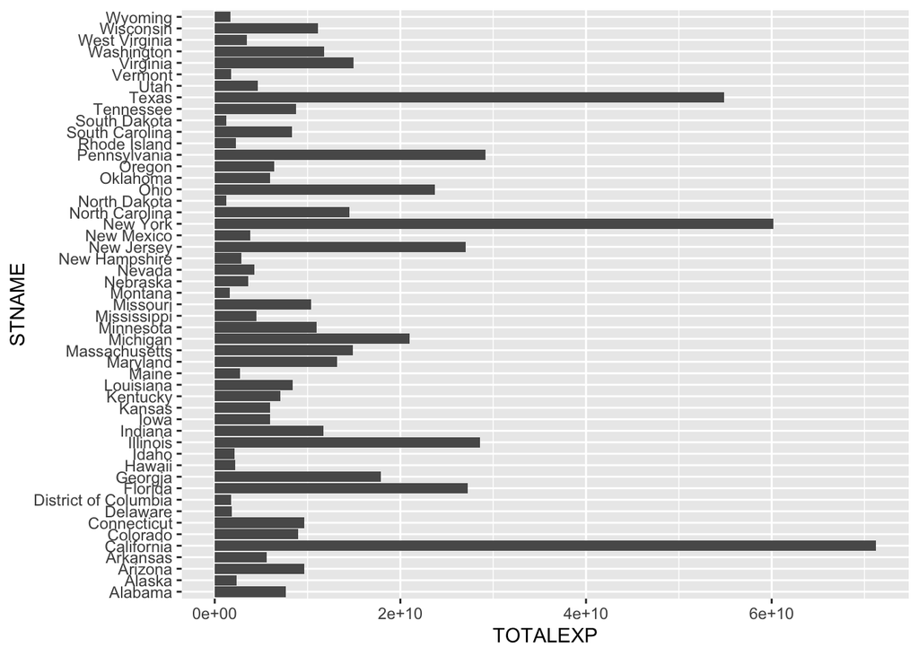

```r
# Total spendings by state
total <-fiscal2010 %>%
  group_by(STNAME) %>%
  summarise(TOTALEXP = sum(TOTALEXP))

total  %>%
  ggplot(aes(TOTALEXP, STNAME)) +
  geom_col()
```

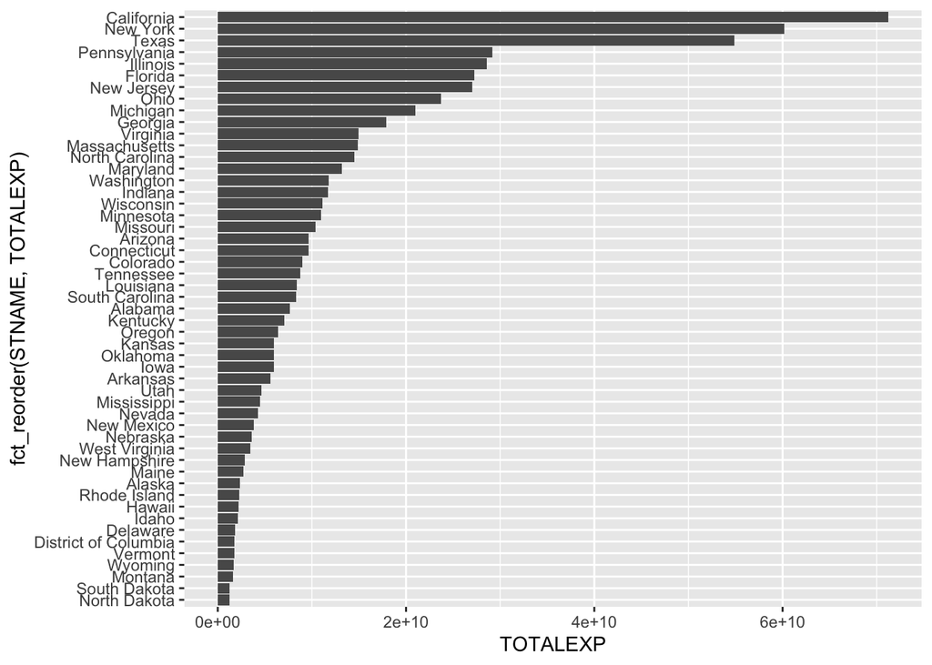

```r
#in descending order
total  %>%
  ggplot(aes(TOTALEXP, fct_reorder(STNAME, TOTALEXP))) +
  geom_col()
```

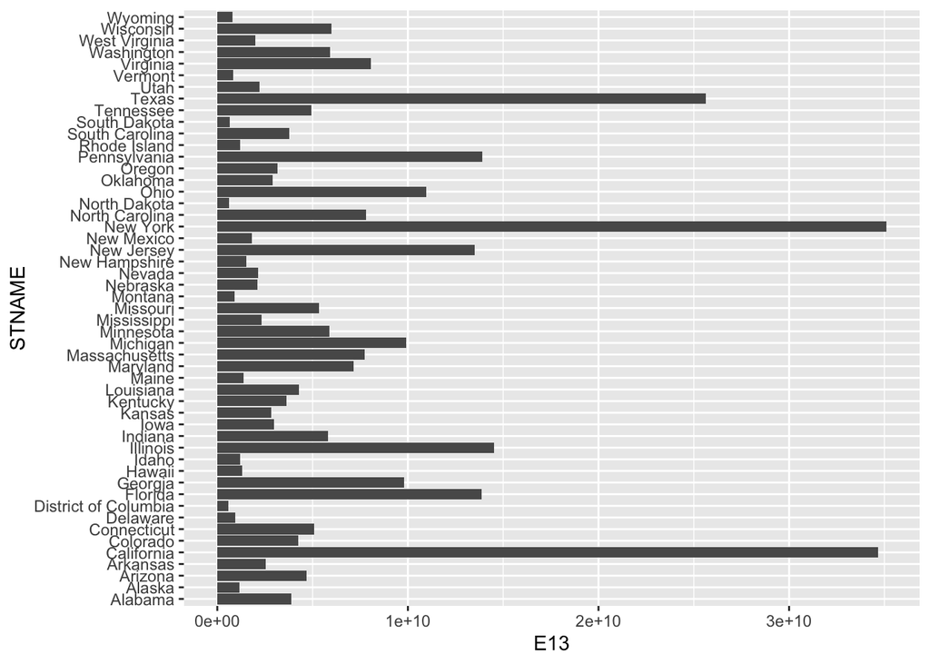

```r
#spending on instruction by state
instruction <- fiscal2010 %>%
  group_by(STNAME) %>%
      summarise(E13 = sum(E13))

instruction  %>%
  ggplot(aes(E13, STNAME)) +
  geom_col()
```

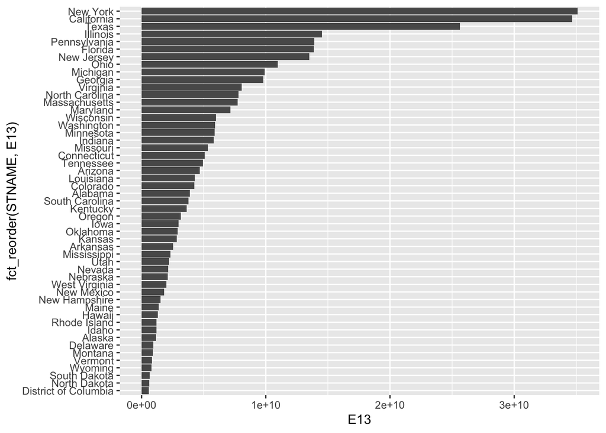

```r
instruction  %>%
  ggplot(aes(E13, fct_reorder(STNAME, E13))) +
  geom_col()
```

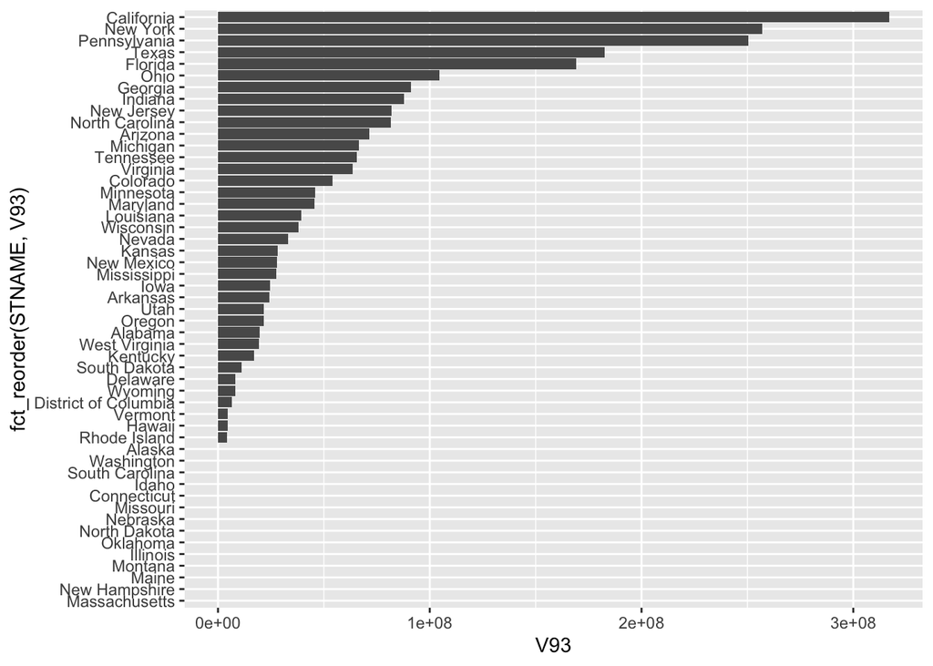

```r
#New York spends more on instruction, while CA spends the most total

#spending on textbooks by state
textbooks <- fiscal2010 %>%
  group_by(STNAME) %>%
      summarise(V93 = sum(V93))

textbooks  %>%
  ggplot(aes(V93, fct_reorder(STNAME, V93))) +
  geom_col()
```

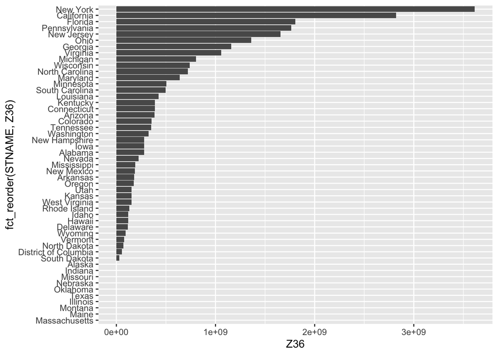

```r
#spending on Special Ed teachers
SpEd <- fiscal2010 %>%
  group_by(STNAME) %>%
      summarise(Z36 = sum(Z36))

SpEd  %>%
  ggplot(aes(Z36, fct_reorder(STNAME, Z36))) +
  geom_col()
```

```r
#next step - figure out how to show those spendings per state as a proportion of the total spending if that state
```

### Data Visualization 3

#### Amy

**Research Question:**

What is the relationship between districts’ local revenue and students’ literacy outcomes on statewide assessments in 2010? I plan on exploring more specific questions that may impact the direction of my final focus and data visualization, including (a) total local revenue vs. local revenue from property taxes, (b) outcomes for specific grades vs. overall, (c) outcomes for specific student race/ethnicity subgroups vs. overall, (e) examining the relationship between funding and outcomes by state, and (e) average local funding (in dollar per student) per state and/or district.

**Datasets:**

- EDFacts_rla_achievement_lea_2010_2019
- NCES_CCD_fiscal_district_2010

```r
# Some initial exploration
#View(rlalea_10)
#View(fiscal2010)

colnames(rlalea_10)
```

```
##   [1] "ALL_RLA00NUMVALID"     "ALL_RLA00PCTPROF"      "ALL_RLA03NUMVALID"
##   [4] "ALL_RLA03PCTPROF"      "ALL_RLA04NUMVALID"     "ALL_RLA04PCTPROF"
##   [7] "ALL_RLA05NUMVALID"     "ALL_RLA05PCTPROF"      "ALL_RLA06NUMVALID"
##  [10] "ALL_RLA06PCTPROF"      "ALL_RLA07NUMVALID"     "ALL_RLA07PCTPROF"
##  [13] "ALL_RLA08NUMVALID"     "ALL_RLA08PCTPROF"      "ALL_RLAHSNUMVALID"
##  [16] "ALL_RLAHSPCTPROF"      "CWD_RLA00NUMVALID"     "CWD_RLA00PCTPROF"
##  [19] "CWD_RLA03NUMVALID"     "CWD_RLA03PCTPROF"      "CWD_RLA04NUMVALID"
##  [22] "CWD_RLA04PCTPROF"      "CWD_RLA05NUMVALID"     "CWD_RLA05PCTPROF"
##  [25] "CWD_RLA06NUMVALID"     "CWD_RLA06PCTPROF"      "CWD_RLA07NUMVALID"
##  [28] "CWD_RLA07PCTPROF"      "CWD_RLA08NUMVALID"     "CWD_RLA08PCTPROF"
##  [31] "CWD_RLAHSNUMVALID"     "CWD_RLAHSPCTPROF"      "ECD_RLA00NUMVALID"
##  [34] "ECD_RLA00PCTPROF"      "ECD_RLA03NUMVALID"     "ECD_RLA03PCTPROF"
##  [37] "ECD_RLA04NUMVALID"     "ECD_RLA04PCTPROF"      "ECD_RLA05NUMVALID"
##  [40] "ECD_RLA05PCTPROF"      "ECD_RLA06NUMVALID"     "ECD_RLA06PCTPROF"
##  [43] "ECD_RLA07NUMVALID"     "ECD_RLA07PCTPROF"      "ECD_RLA08NUMVALID"
```

[output cut: 63 more lines]

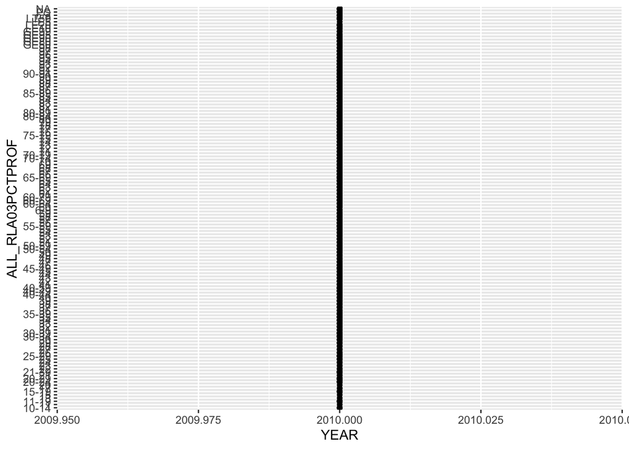

```r
rlalea_10  %>%
  ggplot(aes(YEAR, ALL_RLA03PCTPROF)) +
             geom_point()
```

```r
unique(rlalea_10$YEAR)
```

```
## [1] 2010
```

```r
skim(rlalea_10)
```

Data summary

| Name | rlalea_10 |
| --- | --- |
| Number of rows | 15717 |
| Number of columns | 232 |
| _______________________ |  |
| Column type frequency: |  |
| character | 118 |
| numeric | 113 |
| POSIXct | 1 |
| ________________________ |  |
| Group variables | None |

**Variable type: character**

| skim_variable | n_missing | complete_rate | min | max | empty | n_unique | whitespace |
| --- | --- | --- | --- | --- | --- | --- | --- |
| ALL_RLA00PCTPROF | 0 | 1.00 | 1 | 5 | 0 | 132 | 0 |
| ALL_RLA03PCTPROF | 1339 | 0.91 | 2 | 5 | 0 | 123 | 0 |
| ALL_RLA04PCTPROF | 1342 | 0.91 | 2 | 5 | 0 | 117 | 0 |
| ALL_RLA05PCTPROF | 1335 | 0.92 | 2 | 5 | 0 | 118 | 0 |
| ALL_RLA06PCTPROF | 1333 | 0.92 | 2 | 5 | 0 | 116 | 0 |
| ALL_RLA07PCTPROF | 1770 | 0.89 | 2 | 5 | 0 | 117 | 0 |
| ALL_RLA08PCTPROF | 1818 | 0.88 | 2 | 5 | 0 | 117 | 0 |
| ALL_RLAHSPCTPROF | 3683 | 0.77 | 2 | 5 | 0 | 118 | 0 |
| CWD_RLA00PCTPROF | 187 | 0.99 | 1 | 5 | 0 | 127 | 0 |
| CWD_RLA03PCTPROF | 1996 | 0.87 | 2 | 5 | 0 | 118 | 0 |
| CWD_RLA04PCTPROF | 1986 | 0.87 | 1 | 5 | 0 | 109 | 0 |
| CWD_RLA05PCTPROF | 1994 | 0.87 | 1 | 5 | 0 | 117 | 0 |
| CWD_RLA06PCTPROF | 2018 | 0.87 | 1 | 5 | 0 | 109 | 0 |
| CWD_RLA07PCTPROF | 2374 | 0.85 | 1 | 5 | 0 | 102 | 0 |
| CWD_RLA08PCTPROF | 2448 | 0.84 | 2 | 5 | 0 | 101 | 0 |
| CWD_RLAHSPCTPROF | 4133 | 0.74 | 1 | 5 | 0 | 99 | 0 |
| ECD_RLA00PCTPROF | 401 | 0.97 | 1 | 5 | 0 | 123 | 0 |
| ECD_RLA03PCTPROF | 1766 | 0.89 | 2 | 5 | 0 | 121 | 0 |
| ECD_RLA04PCTPROF | 1749 | 0.89 | 2 | 5 | 0 | 115 | 0 |
| ECD_RLA05PCTPROF | 1731 | 0.89 | 2 | 5 | 0 | 114 | 0 |
| ECD_RLA06PCTPROF | 1749 | 0.89 | 2 | 5 | 0 | 114 | 0 |
| ECD_RLA07PCTPROF | 2155 | 0.86 | 2 | 5 | 0 | 113 | 0 |
| ECD_RLA08PCTPROF | 2198 | 0.86 | 2 | 5 | 0 | 120 | 0 |
| ECD_RLAHSPCTPROF | 3966 | 0.75 | 2 | 5 | 0 | 119 | 0 |
| FIPST | 0 | 1.00 | 2 | 2 | 0 | 51 | 0 |
| F_RLA00PCTPROF | 40 | 1.00 | 2 | 5 | 0 | 114 | 0 |
| F_RLA03PCTPROF | 1433 | 0.91 | 2 | 5 | 0 | 118 | 0 |
| F_RLA04PCTPROF | 1441 | 0.91 | 2 | 5 | 0 | 108 | 0 |
| F_RLA05PCTPROF | 1442 | 0.91 | 2 | 5 | 0 | 104 | 0 |
| F_RLA06PCTPROF | 1440 | 0.91 | 2 | 5 | 0 | 105 | 0 |

[output cut: 88 more lines]

**Variable type: numeric**

| skim_variable | n_missing | complete_rate | mean | sd | p0 | p25 | p50 | p75 | p100 | hist |
| --- | --- | --- | --- | --- | --- | --- | --- | --- | --- | --- |
| ALL_RLA00NUMVALID | 0 | 1.00 | 1619.22 | 6341.20 | 0 | 150 | 445.0 | 1280.00 | 354300 | ▇▁▁▁▁ |
| ALL_RLA03NUMVALID | 1339 | 0.91 | 254.95 | 959.86 | 0 | 28 | 74.0 | 200.00 | 51708 | ▇▁▁▁▁ |
| ALL_RLA04NUMVALID | 1342 | 0.91 | 254.90 | 950.06 | 0 | 28 | 74.0 | 202.00 | 51714 | ▇▁▁▁▁ |
| ALL_RLA05NUMVALID | 1335 | 0.92 | 251.72 | 937.02 | 0 | 28 | 75.0 | 203.00 | 51447 | ▇▁▁▁▁ |
| ALL_RLA06NUMVALID | 1333 | 0.92 | 250.40 | 919.39 | 0 | 28 | 76.0 | 205.00 | 49186 | ▇▁▁▁▁ |
| ALL_RLA07NUMVALID | 1770 | 0.89 | 257.32 | 940.54 | 0 | 30 | 80.0 | 212.00 | 49820 | ▇▁▁▁▁ |
| ALL_RLA08NUMVALID | 1818 | 0.88 | 258.98 | 933.11 | 0 | 30 | 81.0 | 214.00 | 50401 | ▇▁▁▁▁ |
| ALL_RLAHSNUMVALID | 3683 | 0.77 | 308.21 | 1190.43 | 0 | 38 | 97.0 | 242.00 | 50027 | ▇▁▁▁▁ |
| CWD_RLA00NUMVALID | 187 | 0.99 | 213.74 | 882.36 | 0 | 21 | 60.0 | 174.00 | 58700 | ▇▁▁▁▁ |
| CWD_RLA03NUMVALID | 1996 | 0.87 | 35.38 | 138.53 | 0 | 4 | 11.0 | 29.00 | 9298 | ▇▁▁▁▁ |
| CWD_RLA04NUMVALID | 1986 | 0.87 | 36.67 | 143.98 | 0 | 4 | 11.0 | 30.00 | 9681 | ▇▁▁▁▁ |
| CWD_RLA05NUMVALID | 1994 | 0.87 | 36.30 | 142.77 | 0 | 4 | 11.0 | 30.00 | 9305 | ▇▁▁▁▁ |
| CWD_RLA06NUMVALID | 2018 | 0.87 | 35.11 | 136.29 | 0 | 4 | 11.0 | 29.00 | 8980 | ▇▁▁▁▁ |
| CWD_RLA07NUMVALID | 2374 | 0.85 | 34.99 | 139.13 | 0 | 4 | 11.0 | 29.00 | 9404 | ▇▁▁▁▁ |
| CWD_RLA08NUMVALID | 2448 | 0.84 | 35.00 | 130.36 | 0 | 4 | 12.0 | 30.00 | 7758 | ▇▁▁▁▁ |
| CWD_RLAHSNUMVALID | 4133 | 0.74 | 36.27 | 134.64 | 0 | 5 | 12.0 | 30.00 | 5096 | ▇▁▁▁▁ |
| ECD_RLA00NUMVALID | 401 | 0.97 | 829.43 | 4415.33 | 0 | 64 | 182.0 | 511.00 | 292359 | ▇▁▁▁▁ |
| ECD_RLA03NUMVALID | 1766 | 0.89 | 141.80 | 705.93 | 0 | 12 | 33.0 | 88.00 | 43268 | ▇▁▁▁▁ |
| ECD_RLA04NUMVALID | 1749 | 0.89 | 139.17 | 690.60 | 0 | 12 | 33.0 | 87.00 | 43213 | ▇▁▁▁▁ |
| ECD_RLA05NUMVALID | 1731 | 0.89 | 135.21 | 675.88 | 0 | 12 | 32.0 | 86.00 | 42939 | ▇▁▁▁▁ |
| ECD_RLA06NUMVALID | 1749 | 0.89 | 131.70 | 656.48 | 0 | 12 | 32.0 | 86.00 | 41010 | ▇▁▁▁▁ |
| ECD_RLA07NUMVALID | 2155 | 0.86 | 131.24 | 662.80 | 0 | 13 | 33.0 | 86.00 | 41048 | ▇▁▁▁▁ |
| ECD_RLA08NUMVALID | 2198 | 0.86 | 128.42 | 645.67 | 0 | 12 | 31.0 | 83.00 | 41069 | ▇▁▁▁▁ |
| ECD_RLAHSNUMVALID | 3966 | 0.75 | 130.61 | 707.05 | 0 | 14 | 32.0 | 81.00 | 39812 | ▇▁▁▁▁ |
| F_RLA00NUMVALID | 40 | 1.00 | 791.94 | 3108.78 | 0 | 73 | 219.0 | 622.00 | 173641 | ▇▁▁▁▁ |
| F_RLA03NUMVALID | 1433 | 0.91 | 124.80 | 468.57 | 0 | 14 | 37.0 | 98.00 | 25419 | ▇▁▁▁▁ |
| F_RLA04NUMVALID | 1441 | 0.91 | 124.92 | 465.21 | 0 | 14 | 37.0 | 99.00 | 25380 | ▇▁▁▁▁ |
| F_RLA05NUMVALID | 1442 | 0.91 | 123.40 | 459.09 | 0 | 14 | 37.0 | 100.00 | 25179 | ▇▁▁▁▁ |
| F_RLA06NUMVALID | 1440 | 0.91 | 122.83 | 449.91 | 0 | 14 | 38.0 | 100.00 | 23918 | ▇▁▁▁▁ |
| F_RLA07NUMVALID | 1866 | 0.88 | 126.15 | 459.87 | 0 | 15 | 40.0 | 104.00 | 24487 | ▇▁▁▁▁ |

[output cut: 83 more lines]

**Variable type: POSIXct**

| skim_variable | n_missing | complete_rate | min | max | median | n_unique |
| --- | --- | --- | --- | --- | --- | --- |
| DL_INGESTION_DATETIME | 0 | 1 | 2021-08-20 16:11:49 | 2021-08-20 16:11:49 | 2021-08-20 16:11:49 | 1 |

```r
# Going to need to clean these
rlalea_10 %>%
  group_by(ALL_RLA03PCTPROF) %>%
  summarize(n = n())
```

```
## # A tibble: 124 × 2
##    ALL_RLA03PCTPROF     n
##    <chr>            <int>
##  1 10-14                5
##  2 11                   1
##  3 11-19               24
##  4 13                   1
##  5 15                   1
##  6 15-19               17
##  7 17                   2
##  8 20                   1
##  9 20-24               33
## 10 20-29               57
## # … with 114 more rows
```

```r
# Prelim exploration for fiscal file and local revenue
skim(fiscal2010)
```

Data summary

| Name | fiscal2010 |
| --- | --- |
| Number of rows | 18247 |
| Number of columns | 260 |
| _______________________ |  |
| Column type frequency: |  |
| character | 129 |
| numeric | 130 |
| POSIXct | 1 |
| ________________________ |  |
| Group variables | None |

**Variable type: character**

| skim_variable | n_missing | complete_rate | min | max | empty | n_unique | whitespace |
| --- | --- | --- | --- | --- | --- | --- | --- |
| AGCHRT | 0 | 1 | 1 | 1 | 0 | 4 | 0 |
| CBSA | 0 | 1 | 1 | 5 | 0 | 939 | 0 |
| CENSUSID | 0 | 1 | 1 | 14 | 0 | 14842 | 0 |
| CONUM | 0 | 1 | 5 | 5 | 0 | 3129 | 0 |
| CSA | 0 | 1 | 1 | 3 | 0 | 125 | 0 |
| FIPST | 0 | 1 | 2 | 2 | 0 | 51 | 0 |
| FL_19H | 0 | 1 | 1 | 1 | 0 | 4 | 0 |
| FL_21F | 0 | 1 | 1 | 1 | 0 | 4 | 0 |
| FL_31F | 0 | 1 | 1 | 1 | 0 | 4 | 0 |
| FL_41F | 0 | 1 | 1 | 1 | 0 | 4 | 0 |
| FL_61V | 0 | 1 | 1 | 1 | 0 | 3 | 0 |
| FL_66V | 0 | 1 | 1 | 1 | 0 | 4 | 0 |
| FL_A07 | 0 | 1 | 1 | 1 | 0 | 4 | 0 |
| FL_A08 | 0 | 1 | 1 | 1 | 0 | 3 | 0 |
| FL_A09 | 0 | 1 | 1 | 1 | 0 | 3 | 0 |
| FL_A11 | 0 | 1 | 1 | 1 | 0 | 3 | 0 |
| FL_A13 | 0 | 1 | 1 | 1 | 0 | 3 | 0 |
| FL_A15 | 0 | 1 | 1 | 1 | 0 | 4 | 0 |
| FL_A20 | 0 | 1 | 1 | 1 | 0 | 4 | 0 |
| FL_A40 | 0 | 1 | 1 | 1 | 0 | 4 | 0 |
| FL_B10 | 0 | 1 | 1 | 1 | 0 | 3 | 0 |
| FL_B11 | 0 | 1 | 1 | 1 | 0 | 3 | 0 |
| FL_B12 | 0 | 1 | 1 | 1 | 0 | 4 | 0 |
| FL_B13 | 0 | 1 | 1 | 1 | 0 | 3 | 0 |
| FL_C01 | 0 | 1 | 1 | 1 | 0 | 4 | 0 |
| FL_C04 | 0 | 1 | 1 | 1 | 0 | 4 | 0 |
| FL_C05 | 0 | 1 | 1 | 1 | 0 | 3 | 0 |
| FL_C06 | 0 | 1 | 1 | 1 | 0 | 3 | 0 |
| FL_C07 | 0 | 1 | 1 | 1 | 0 | 4 | 0 |
| FL_C08 | 0 | 1 | 1 | 1 | 0 | 3 | 0 |

[output cut: 99 more lines]

**Variable type: numeric**

| skim_variable | n_missing | complete_rate | mean | sd | p0 | p25 | p50 | p75 | p100 | hist |
| --- | --- | --- | --- | --- | --- | --- | --- | --- | --- | --- |
| A07 | 0 | 1 | 62321.43 | 402543.33 | -2 | 0 | 0 | 9000.0 | 20229000 | ▇▁▁▁▁ |
| A08 | 0 | 1 | 5939.67 | 128277.93 | -2 | 0 | 0 | 0.0 | 15564000 | ▇▁▁▁▁ |
| A09 | 0 | 1 | 364123.59 | 1144107.53 | -2 | 3000 | 79000 | 319000.0 | 47205000 | ▇▁▁▁▁ |
| A11 | 0 | 1 | 10957.26 | 85439.61 | -2 | 0 | 0 | 0.0 | 3510000 | ▇▁▁▁▁ |
| A13 | 0 | 1 | 211909.26 | 1823605.27 | -2 | 0 | 8000 | 97000.0 | 171949000 | ▇▁▁▁▁ |
| A15 | 0 | 1 | 8501.85 | 191879.04 | -2 | 0 | 0 | 0.0 | 14939000 | ▇▁▁▁▁ |
| A20 | 0 | 1 | 91805.46 | 808818.77 | -2 | 0 | 0 | 3000.0 | 49072000 | ▇▁▁▁▁ |
| A40 | 0 | 1 | 41828.48 | 293969.27 | -2 | 0 | 0 | 9000.0 | 19348000 | ▇▁▁▁▁ |
| B10 | 0 | 1 | 68834.01 | 917277.92 | -2 | 0 | 0 | 0.0 | 59398000 | ▇▁▁▁▁ |
| B11 | 0 | 1 | 19931.51 | 259028.50 | -2 | 0 | 0 | 0.0 | 28169000 | ▇▁▁▁▁ |
| B12 | 0 | 1 | 5454.66 | 56806.67 | -2 | 0 | 0 | 0.0 | 3111000 | ▇▁▁▁▁ |
| B13 | 0 | 1 | 162690.86 | 2006666.21 | -2 | 0 | 0 | 24000.0 | 213069000 | ▇▁▁▁▁ |
| C01 | 0 | 1 | 9904463.16 | 56726682.92 | -2 | 481000 | 2407000 | 7717500.0 | 6016802000 | ▇▁▁▁▁ |
| C04 | 0 | 1 | 177204.10 | 1791292.67 | -2 | 0 | 0 | 0.0 | 139157000 | ▇▁▁▁▁ |
| C05 | 0 | 1 | 918167.93 | 12489751.14 | -2 | 0 | 0 | 331000.0 | 1445472000 | ▇▁▁▁▁ |
| C06 | 0 | 1 | 255034.54 | 3212965.61 | -2 | 0 | 0 | 47000.0 | 262095000 | ▇▁▁▁▁ |
| C07 | 0 | 1 | 33335.24 | 848165.31 | -2 | 0 | 0 | 0.0 | 52887000 | ▇▁▁▁▁ |
| C08 | 0 | 1 | 23623.02 | 667675.15 | -2 | 0 | 0 | 0.0 | 68096000 | ▇▁▁▁▁ |
| C09 | 0 | 1 | 43071.09 | 351589.50 | -2 | 0 | 0 | 0.0 | 16140000 | ▇▁▁▁▁ |
| C10 | 0 | 1 | 28732.95 | 385107.93 | -2 | 0 | 2000 | 12000.0 | 42871000 | ▇▁▁▁▁ |
| C11 | 0 | 1 | 340673.71 | 3307919.59 | -2 | 0 | 0 | 0.0 | 289060000 | ▇▁▁▁▁ |
| C12 | 0 | 1 | 219562.73 | 1235888.02 | -2 | 0 | 0 | 68000.0 | 76286000 | ▇▁▁▁▁ |
| C13 | 0 | 1 | 1467624.72 | 15568842.66 | -2 | 1000 | 76000 | 506000.0 | 1684314000 | ▇▁▁▁▁ |
| C14 | 0 | 1 | 928407.42 | 8605443.22 | -2 | 23000 | 146000 | 508000.0 | 777993000 | ▇▁▁▁▁ |
| C15 | 0 | 1 | 783204.43 | 4229045.40 | -2 | 0 | 69000 | 473000.0 | 257678000 | ▇▁▁▁▁ |
| C16 | 0 | 1 | 91089.01 | 662844.07 | -2 | 0 | 0 | 43000.0 | 58822000 | ▇▁▁▁▁ |
| C17 | 0 | 1 | 13732.90 | 128064.08 | -2 | 0 | 0 | 4500.0 | 10177000 | ▇▁▁▁▁ |
| C19 | 0 | 1 | 34663.02 | 223558.75 | -2 | 0 | 0 | 2000.0 | 15750000 | ▇▁▁▁▁ |
| C20 | 0 | 1 | 1216737.06 | 6249021.27 | -2 | 1000 | 178000 | 753000.0 | 394540000 | ▇▁▁▁▁ |
| C24 | 0 | 1 | 198884.54 | 5846320.83 | -2 | 0 | 0 | 0.0 | 729737000 | ▇▁▁▁▁ |

[output cut: 100 more lines]

**Variable type: POSIXct**

| skim_variable | n_missing | complete_rate | min | max | median | n_unique |
| --- | --- | --- | --- | --- | --- | --- |
| DL_INGESTION_DATETIME | 0 | 1 | 2021-09-02 13:02:24 | 2021-09-02 13:02:24 | 2021-09-02 13:02:24 | 1 |

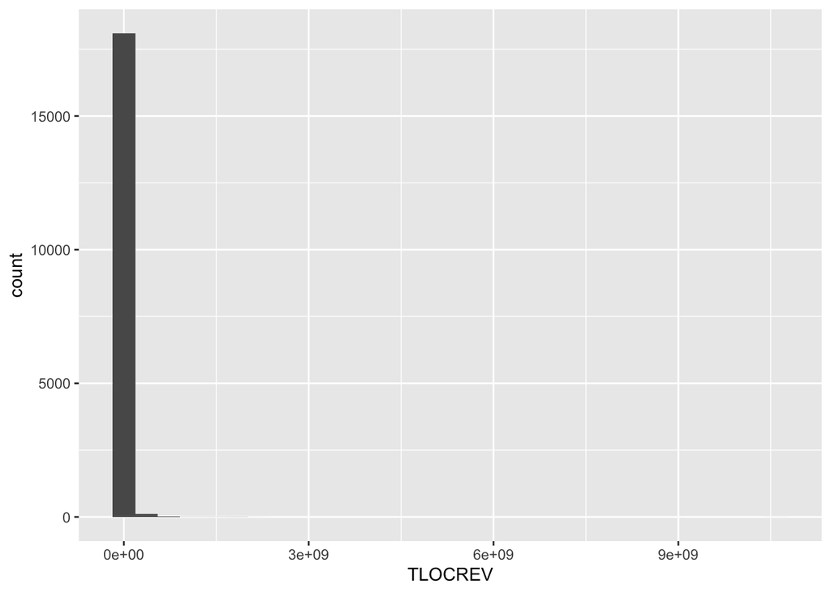

```r
# Total local revenue (need to adjust x-axis)
fiscal2010 %>%
  ggplot(aes(TLOCREV)) +
  geom_histogram()
```

```r
fiscal2010 %>%
  group_by(LEAID) %>%
  summarize(TLOCREV)
```

```
## # A tibble: 18,247 × 2
##    LEAID    TLOCREV
##    <chr>      <dbl>
##  1 0100002       -2
##  2 0100005 12985000
##  3 0100006 13030000
##  4 0100007 86143000
##  5 0100008 35532000
##  6 0100009       -2
##  7 0100011  4820000
##  8 0100012  6964000
##  9 0100013 16766000
## 10 0100015       -2
## # … with 18,237 more rows
```

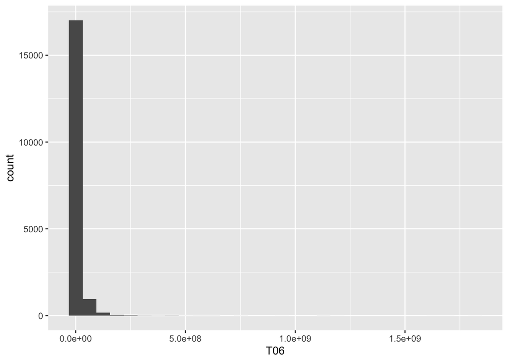

```r
# Exploring local revenue solely from property taxes
fiscal2010 %>%
  ggplot(aes(T06)) +
  geom_histogram()
```

```r
fiscal2010 %>%
  group_by(LEAID) %>%
  summarize(T06)
```

```
## # A tibble: 18,247 × 2
##    LEAID        T06
##    <chr>      <dbl>
##  1 0100002       -2
##  2 0100005  3071000
##  3 0100006  6450000
##  4 0100007 65472000
##  5 0100008 15163000
##  6 0100009       -2
##  7 0100011  3527000
##  8 0100012  2443000
##  9 0100013 10554000
## 10 0100015       -2
## # … with 18,237 more rows
```

```r
# Local funding in property tax per student
fiscal2010 <- fiscal2010 %>%
  mutate(taxperstu = T06/V33)

fiscal2010$taxperstu
```

[output not shown]

[output cut: 3635 more lines]

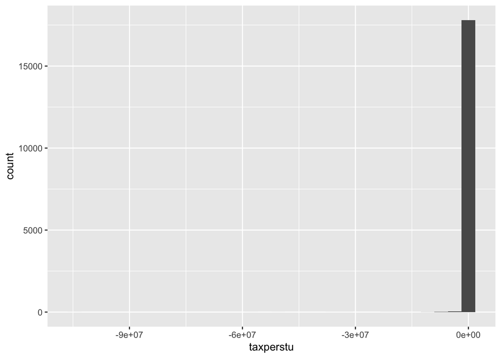

```r
fiscal2010 %>%
  ggplot(aes(taxperstu)) +
  geom_histogram()
```

```r
fiscal2010 %>%
  group_by(LEAID) %>%
  summarize(taxperstu)
```

```
## # A tibble: 18,247 × 2
##    LEAID   taxperstu
##    <chr>       <dbl>
##  1 0100002     -Inf
##  2 0100005      748.
##  3 0100006     1116.
##  4 0100007     5080.
##  5 0100008     1752.
##  6 0100009     -Inf
##  7 0100011     2414.
##  8 0100012     1061.
##  9 0100013     2543.
## 10 0100015     -Inf
## # … with 18,237 more rows
```

```r
# I don't think this works b/c I need to clean values for the property tax variable before calculating tax per student
fiscal2010 %>%
  summarize(min_taxperstu = min(taxperstu),
            max_taxperstu = max(taxperstu))
```

```
## # A tibble: 1 × 2
##   min_taxperstu max_taxperstu
##           <dbl>         <dbl>
## 1           NaN           NaN
```